# Juggling between tidy and non tidy forms

Saumya Mehta

5/15/2018

## Tidying a document term matrix

- Each row represents one document
- Each column represents one term
- Each value (typically) contains the number of appearances of that term in that document.  
  DTMs are usually sparse matrices. DTMs cannot be used directly with tidy tools. Two Packages to convert between two formats :  
  1.) tidy() : dtm to tidy data  
  2.) cast() : tidy data to dtm (cast_sparse(), cast_dtm(), cast_dfm())

## Tidying dtm object

DocumentTermMatrix class from tm packages.

```r
library(tm)
data("AssociatedPress", package = "topicmodels")

AssociatedPress
```

```
## <<DocumentTermMatrix (documents: 2246, terms: 10473)>>
## Non-/sparse entries: 302031/23220327
## Sparsity           : 99%
## Maximal term length: 18
## Weighting          : term frequency (tf)
```

Access the terms in a dtm using Terms() function.

```r
terms <- Terms(AssociatedPress)
head(terms)
```

```
## [1] "aaron"      "abandon"    "abandoned"  "abandoning" "abbott"
## [6] "abboud"
```

To analyse with tidy tools, we need to convert it into tidy data using tidy(dtm object).

```r
library(dplyr)
library(tidytext)
ap_td <- tidy(AssociatedPress)

ap_td
```

```
## # A tibble: 302,031 x 3
##    document term       count
##       <int> <chr>      <dbl>
##  1        1 adding        1.
##  2        1 adult         2.
##  3        1 ago           1.
##  4        1 alcohol       1.
##  5        1 allegedly     1.
##  6        1 allen         1.
##  7        1 apparently    2.
##  8        1 appeared      1.
##  9        1 arrested      1.
## 10        1 assault       1.
## # ... with 302,021 more rows
```

Tidied version has no rows where count = 0. This form is convinient for analysis with dplyr, tidytext and ggplot2.

```r
ap_sentiments <- ap_td %>%
  inner_join(get_sentiments("bing"), by = c(term = "word"))

ap_sentiments
```

```
## # A tibble: 30,094 x 4
##    document term    count sentiment
##       <int> <chr>   <dbl> <chr>
##  1        1 assault    1. negative
##  2        1 complex    1. negative
##  3        1 death      1. negative
##  4        1 died       1. negative
##  5        1 good       2. positive
##  6        1 illness    1. negative
##  7        1 killed     2. negative
##  8        1 like       2. positive
##  9        1 liked      1. positive
## 10        1 miracle    1. positive
## # ... with 30,084 more rows
```

Analysing contribution to the sentiment.

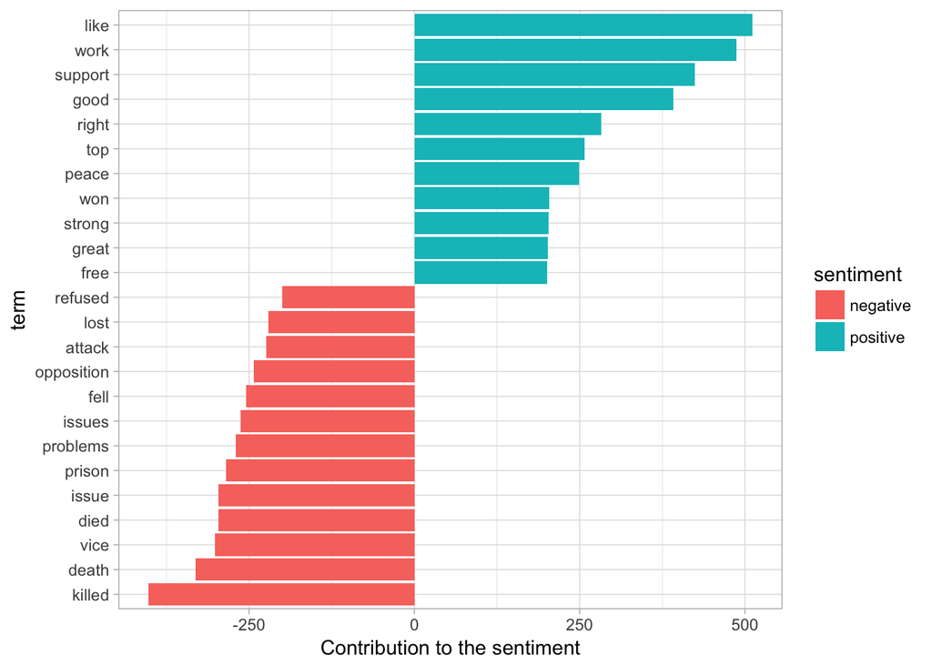

Figure 5.1: Words from AP articles with the greatest contribution to positive or negative sentiments, using the Bing sentiment lexicon

## Tidying dfm objects

Document Feature Matrix class from quanteda package.

```r
library(quanteda)
data("data_corpus_inaugural", package = "quanteda")
inaug_dfm <- dfm(data_corpus_inaugural, verbose = F)

inaug_tidy <- tidy(inaug_dfm)

inaug_tidy
```

```
## # A tibble: 44,709 x 3
##    document        term            count
##    <chr>           <chr>           <dbl>
##  1 1789-Washington fellow-citizens    1.
##  2 1797-Adams      fellow-citizens    3.
##  3 1801-Jefferson  fellow-citizens    2.
##  4 1809-Madison    fellow-citizens    1.
##  5 1813-Madison    fellow-citizens    1.
##  6 1817-Monroe     fellow-citizens    5.
##  7 1821-Monroe     fellow-citizens    1.
##  8 1841-Harrison   fellow-citizens   11.
##  9 1845-Polk       fellow-citizens    1.
## 10 1849-Taylor     fellow-citizens    1.
## # ... with 44,699 more rows
```

We can find the words most specific to each inaugural speeches using tf-idf mapping.

```r
inaug_tf_idf <- inaug_tidy %>%
  bind_tf_idf(term,document,count) %>%
  arrange(desc(tf_idf))

inaug_tf_idf
```

```
## # A tibble: 44,709 x 6
##    document        term        count      tf   idf tf_idf
##    <chr>           <chr>       <dbl>   <dbl> <dbl>  <dbl>
##  1 1793-Washington arrive         1. 0.00680  4.06 0.0276
##  2 1793-Washington upbraidings    1. 0.00680  4.06 0.0276
##  3 1793-Washington violated       1. 0.00680  3.37 0.0229
##  4 1793-Washington willingly      1. 0.00680  3.37 0.0229
##  5 1793-Washington incurring      1. 0.00680  3.37 0.0229
##  6 1793-Washington previous       1. 0.00680  2.96 0.0201
##  7 1793-Washington knowingly      1. 0.00680  2.96 0.0201
##  8 1793-Washington injunctions    1. 0.00680  2.96 0.0201
##  9 1793-Washington witnesses      1. 0.00680  2.96 0.0201
## 10 1793-Washington besides        1. 0.00680  2.67 0.0182
## # ... with 44,699 more rows
```

tidyr’s complete() function is used to include zeros where the word didn’t appear in the document.

```r
library(tidyr)
year_term_counts <- inaug_tidy %>%
  extract(document, "year","(\\d+)",convert = T) %>%
  complete(year, term, fill = list(count = 0)) %>%
  group_by(year) %>%
  mutate(year_total = sum(count))
```

Here we pick up a few words and check how they changed in frequency over time.

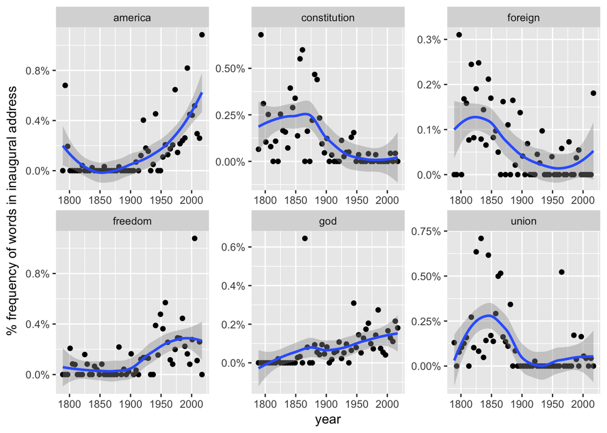

## Casting tidytext data into a matrix

```r
ap_td %>%
  cast_dtm(document, term, count)
```

```
## <<DocumentTermMatrix (documents: 2246, terms: 10473)>>
## Non-/sparse entries: 302031/23220327
## Sparsity           : 99%
## Maximal term length: 18
## Weighting          : term frequency (tf)
```

```r
ap_td %>%
  cast_dfm(document, term, count)
```

```
## Document-feature matrix of: 2,246 documents, 10,473 features (98.7% sparse).
```

```r
library(Matrix)
# cast into a Matrix object
m <- ap_td %>%
  cast_sparse(document, term, count)

class(m)
```

```
## [1] "dgCMatrix"
## attr(,"package")
## [1] "Matrix"
```

```r
dim(m)
```

```
## [1]  2246 10473
```

```r
library(janeaustenr)

austen_dtm <- austen_books() %>%
  unnest_tokens(word, text) %>%
  count(book, word) %>%
  cast_dtm(book, word, n)

austen_dtm
```

```
## <<DocumentTermMatrix (documents: 6, terms: 14520)>>
## Non-/sparse entries: 40379/46741
## Sparsity           : 54%
## Maximal term length: 19
## Weighting          : term frequency (tf)
```

## Tidying corpus objects with metadata

A corpus object is structured like a list each containing both text and metadata. This is a flexible method os storage for documents but doesn’t lend itself to processing with tidy tools.  
We can thus use the tidy() method to construct a table with one row per document, including the metadata (such as id and datetimestamp) as columns alongside the text